# Data analysis Casasanto 2009’s replication

# Supplementary analysis

See rationale in the manuscript.

## Classification algorithms

### One rule

```r
library(OneR)

model1 <-
  with(data.complete2,
  as.formula(good_right ~ age + gender + hand_score +
                 quest_ver + modality +
                 lab))


# 1R approach
cat.rank <- OneR(model1,
                 verbose=T, data = data.complete2)
```

```
##
##     Attribute  Accuracy
## 1 * hand_score 60.84%
## 1   quest_ver  60.84%
## 3   lab        59.97%
## 4   age        59.43%
## 5   gender     59.38%
## 5   modality   59.38%
## ---
## Chosen attribute due to accuracy
## and ties method (if applicable): '*'
```

```r
cat.rank
```

```
##
## Call:
## OneR.formula(formula = model1, data = data.complete2, verbose = T)
##
## Rules:
## If hand_score = (-10,-6] then good_right = 0
## If hand_score = (-6,-2]  then good_right = 0
## If hand_score = (-2,2]   then good_right = 1
## If hand_score = (2,6]    then good_right = 1
## If hand_score = (6,10]   then good_right = 1
##
## Accuracy:
## 1339 of 2201 instances classified correctly (60.84%)
```

```r
summary(cat.rank)
```

```
##
## Call:
## OneR.formula(formula = model1, data = data.complete2, verbose = T)
##
## Rules:
## If hand_score = (-10,-6] then good_right = 0
## If hand_score = (-6,-2]  then good_right = 0
## If hand_score = (-2,2]   then good_right = 1
## If hand_score = (2,6]    then good_right = 1
## If hand_score = (6,10]   then good_right = 1
##
## Accuracy:
## 1339 of 2201 instances classified correctly (60.84%)
##
## Contingency table:
##           hand_score
## good_right (-10,-6] (-6,-2] (-2,2] (2,6] (6,10]  Sum
##        0       * 84    * 17     14    27    752  894
##        1         57      12   * 17  * 35 * 1186 1307
##        Sum      141      29     31    62   1938 2201
## ---
## Maximum in each column: '*'
##
## Pearson's Chi-squared test:
## X-squared = 28.037, df = 4, p-value = 1.226e-05
```

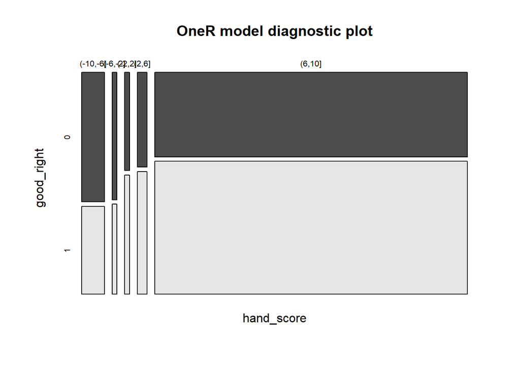

```r
plot(cat.rank)
```

The 1R algorithm lists both `hand_score` and `quest_ver` in the first place. Both with a classification accuracy of 60.84%. `lab` occupied the 3rd place with a classification accuracy of 59.97%.

### Boruta

```r
library(Boruta)
set.seed(2022)

boruta.selection <- Boruta(model1,
                 data = data.complete2)

print(boruta.selection)
```

```
## Boruta performed 17 iterations in 11.88031 secs.
##  5 attributes confirmed important: age, hand_score, lab, modality,
## quest_ver;
##  1 attributes confirmed unimportant: gender;
```

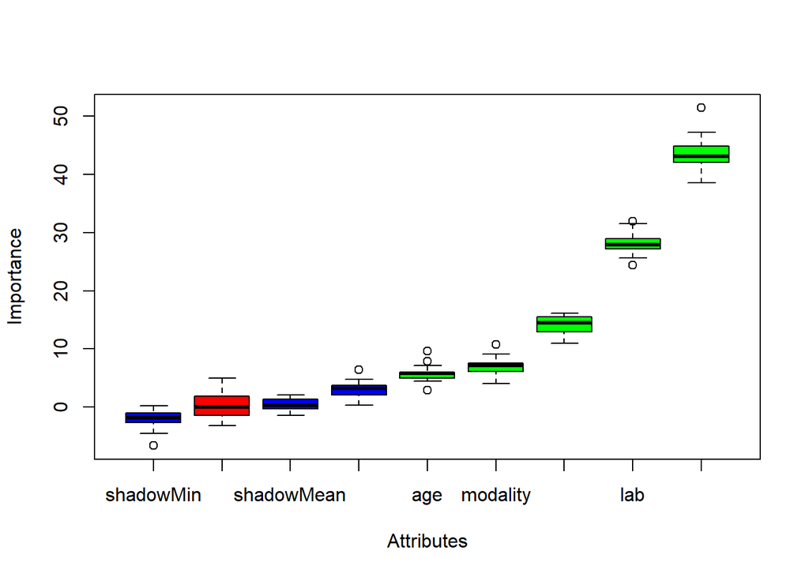

```r
plot(boruta.selection)
```

```r
# Recall: green are confirmed variables
#         red are rejected variables
#         blue are shadow variables
# The Y axis represents level of importance

getConfirmedFormula(boruta.selection)
```

```
## good_right ~ age + hand_score + quest_ver + modality + lab
## <environment: 0x000001f535e60d38>
```

```r
ranking.variables <- attStats(boruta.selection)

ranking.variables[order(ranking.variables$medianImp,
                        decreasing = T),]
```

|  | meanImp | medianImp | minImp | maxImp | normHits | decision |
| --- | --- | --- | --- | --- | --- | --- |
| quest_ver | 43.4375438 | 43.11028096 | 38.536517 | 51.417564 | 1.0000000 | Confirmed |
| lab | 28.1161116 | 27.95150771 | 24.430849 | 31.920284 | 1.0000000 | Confirmed |
| hand_score | 14.1161542 | 14.52172510 | 11.020014 | 16.170410 | 1.0000000 | Confirmed |
| modality | 7.0636722 | 7.20022002 | 4.111012 | 10.774435 | 1.0000000 | Confirmed |
| age | 5.7603759 | 5.82123980 | 2.932809 | 9.672965 | 1.0000000 | Confirmed |
| gender | 0.3141268 | 0.07887019 | -3.208985 | 4.972374 | 0.1176471 | Rejected |

The Boruta algorithm ranks the importance of variables, in this order, as `quest_ver`, `lab` and `hand_score`.

The two common variables were `quest_ver` and `hand_score`. A logistic model considering these two variables was already examined in the section ‘simplified model’ and therefore will not be pursued further.

# Overall message:

- The likelihood of choosing ‘right-is-good’ increases as the score in the FLANDERS handedness test increases.
- However, that likelihood is not strikingly large (nearing 1).